# Initial Analyses

### Explore possible non-linear relationships between predictors and response

**Approach:** Model as additive model; because additive models consume a large number of degrees of freedom, with a data set with this many predictors relative to data points, it is not possible to model all predictors at once. We can madel about 7 or 8 smoothed predictors with the df available, e.g.:

```r
mod.gam1 <- gam(revenue ~ s(weekno) + s(displayimp) + s(displaylag) + s(brandpaid) +
                s(brandclicks) + s(nonbrandpaid) + s(nonbrandclicks), data = train)
summary(mod.gam1)
```

```
##
## Family: gaussian
## Link function: identity
##
## Formula:
## revenue ~ s(weekno) + s(displayimp) + s(displaylag) + s(brandpaid) +
##     s(brandclicks) + s(nonbrandpaid) + s(nonbrandclicks)
##
## Parametric coefficients:
##             Estimate Std. Error t value Pr(>|t|)
## (Intercept)   145722       1621   89.87   <2e-16 ***
## ---
## Signif. codes:  0 '***' 0.001 '**' 0.01 '*' 0.05 '.' 0.1 ' ' 1
##
## Approximate significance of smooth terms:
##                     edf Ref.df     F  p-value
## s(weekno)         6.628  7.709 6.852 2.76e-06 ***
## s(displayimp)     1.648  1.835 1.184   0.2292
## s(displaylag)     2.034  2.119 3.064   0.0505 .
## s(brandpaid)      1.431  1.749 0.199   0.7628
## s(brandclicks)    2.672  3.330 3.771   0.0125 *
## s(nonbrandpaid)   1.000  1.000 0.267   0.6070
## s(nonbrandclicks) 1.000  1.000 0.003   0.9580
## ---
## Signif. codes:  0 '***' 0.001 '**' 0.01 '*' 0.05 '.' 0.1 ' ' 1
##
## R-sq.(adj) =  0.646   Deviance explained = 72.3%
## GCV = 2.5918e+08  Scale est. = 1.998e+08  n = 76
```

```r
predictors <- names(train)[-1]

# Do not include binary variables at this point
binVars <- c(
  'highseason', 'holiday', 'autoenroll', 'socialperson', 'promoteposts', 'learner')
predictors <- predictors[-which(predictors %in% binVars)]

# Also exclude Week, weekno from predictors here, as these will always be unique
# values (never repeated), so we don't want extrapolate
predictors <- predictors[-c(1, 2)]

np <- 7
iterations <- 10 # reduced here to knit file, actually ran several thousand
```

Keep track of the best 3 models. Uncomment the following 2 lines for first run only, then comment out so best data is not overwritten

```r
#bestGCV <- c(Inf, Inf, Inf)
#bestMods <-  c('', '', '')

for (i in 1:iterations) {
  sampP <- sample(predictors, np)
  form <- 'revenue ~'

  for (p in sampP) {
    form <- paste(form, ' + s(', p, ')', sep = '')
  }

  mod <- gam(as.formula(form), data = train)

  # Quality of the model will be determined by generalized cross-validation (gcv)
  if (mod$gcv.ubre < bestGCV[3]) {
    if (mod$gcv.ubre < bestGCV[2]) {
      if (mod$gcv.ubre < bestGCV[1]) {
        # insert in first place, bump others
        bestGCV[3] <- bestGCV[2]
        bestGCV[2] <- bestGCV[1]
        bestGCV[1] <- mod$gcv.ubre
        bestMods[3] <- bestMods[2]
        bestMods[2] <- bestMods[1]
        bestMods[1] <- form
      } else {
        # insert in second place, bump other
        bestGCV[3] <- bestGCV[2]
        bestGCV[2] <- mod$gcv.ubre
        bestMods[3] <- bestMods[2]
        bestMods[2] <- form
      }
    } else {
      # insert in third place; no bumping
      bestGCV[3] <- mod$gcv.ubre
      bestMods[3] <- form
    }
  }
}

bestGCV
```

```
## [1] 189510781 193485293 202291203
```

NOTE: bestGCVs were saved in save.image at the bottom of this file. These are the best after several thousand iterations not just the 10 iterations run here.

Now let's observe the significantly non-linear terms found in these best models.

```r
bestMod3 <- gam(as.formula(bestMods[3]), data = train)
bestMod2 <- gam(as.formula(bestMods[2]), data = train)
bestMod1 <- gam(as.formula(bestMods[1]), data = train)
summary(bestMod3)
```

[output not shown]

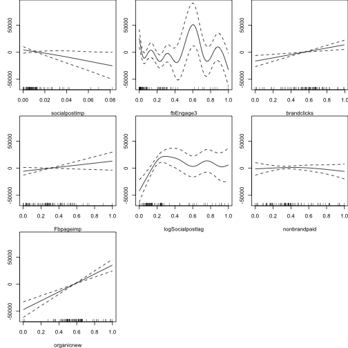

```r
par(mfrow = c(3, 3))
par(mar = c(4, 3, 0, 0))
plot(bestMod3)
```

```r
summary(bestMod2)
```

```
##
## Family: gaussian
## Link function: identity
##
## Formula:
## revenue ~ +s(Fbpostimp) + s(socialpostlag) + s(organicnew) +
##     s(weekOfYear) + s(nonbrandpaid) + s(youtubelag) + s(rev1weekAgo)
##
## Parametric coefficients:
##             Estimate Std. Error t value Pr(>|t|)
## (Intercept)   145945       1250   116.7   <2e-16 ***
## ---
## Signif. codes:  0 '***' 0.001 '**' 0.01 '*' 0.05 '.' 0.1 ' ' 1
##
## Approximate significance of smooth terms:
##                    edf Ref.df     F  p-value
## s(Fbpostimp)     7.115  8.043 2.372   0.0291 *
## s(socialpostlag) 7.917  8.574 2.212   0.0227 *
## s(organicnew)    3.159  3.826 7.934 4.36e-05 ***
## s(weekOfYear)    2.123  2.621 0.773   0.4285
## s(nonbrandpaid)  2.070  2.581 1.383   0.2841
## s(youtubelag)    1.103  1.191 0.228   0.7419
## s(rev1weekAgo)   3.522  4.371 1.570   0.1840
## ---
## Signif. codes:  0 '***' 0.001 '**' 0.01 '*' 0.05 '.' 0.1 ' ' 1
##
## R-sq.(adj) =  0.765   Deviance explained = 84.4%
## GCV = 1.9349e+08  Scale est. = 1.2658e+08  n = 81
```

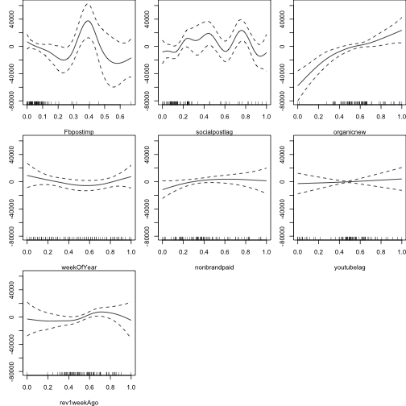

```r
# Commented out quartz lines for knitting
#quartz()
par(mfrow = c(3, 3))
par(mar = c(4, 3, 0, 0))
plot(bestMod2)
```

```r
summary(bestMod1)
```

```
##
## Family: gaussian
## Link function: identity
##
## Formula:
## revenue ~ +s(blogrefernew) + s(youtube) + s(nonbrandclicks) +
##     s(fbengagelag) + s(logOrganicnew) + s(TWimpLag) + s(sinWeekOfYear)
##
## Parametric coefficients:
##             Estimate Std. Error t value Pr(>|t|)
## (Intercept)   146610       1382   106.1   <2e-16 ***
## ---
## Signif. codes:  0 '***' 0.001 '**' 0.01 '*' 0.05 '.' 0.1 ' ' 1
##
## Approximate significance of smooth terms:
##                     edf Ref.df      F  p-value
## s(blogrefernew)   1.908  2.383  1.050  0.36640
## s(youtube)        2.213  2.715  1.812  0.11386
## s(nonbrandclicks) 3.973  4.879  2.002  0.08852 .
## s(fbengagelag)    1.000  1.000  1.515  0.22301
## s(logOrganicnew)  1.549  1.885 33.863 1.34e-09 ***
## s(TWimpLag)       4.006  4.903  1.785  0.09866 .
## s(sinWeekOfYear)  1.000  1.000  7.259  0.00904 **
## ---
## Signif. codes:  0 '***' 0.001 '**' 0.01 '*' 0.05 '.' 0.1 ' ' 1
##
## R-sq.(adj) =  0.732   Deviance explained = 78.7%
## GCV = 1.8951e+08  Scale est. = 1.4906e+08  n = 78
```

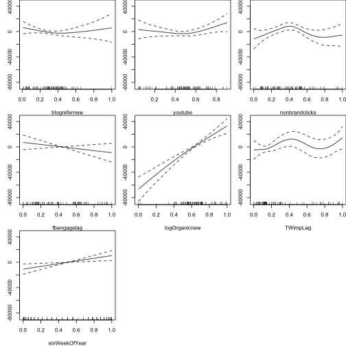

```r
#quartz()
par(mfrow = c(3, 3))
par(mar = c(4, 3, 0, 0))
plot(bestMod1)
```

If we look at the predictors found to be significant in these top models, a few non-linear relationships are suggested

- fbengage: approximately cubic
- socialpostlag: early increase then basically flat
- organicnew: roughly quadratic or log-like
- blognewusers: roughly quadratic or reciprocal (though it seems unlikely that an increase in new blog users would lead to a decrease in revenue)
- Fbpostimp: This looks suspiciously overfitted, and there are not a lot of data points contributing to the area of high curvature. At the left end of the graph, where most of the data lie, there is a roughly quadratic fit, but this does not fit the remaining data points.
- Fbpostimplag: roughly quadratic
- weekOfYear: as mentioned when exploring the temporal correlation (in nuggetPreprocess.R), these models also suggest that revenue is lowest at mid year, and highest in the winter; could be approximated with a quadratic or perhaps sinusoid
- Twpostimp: quadratic or log

### Construct new variables:

- fbengage<sup>3</sup> • socialpostlag / (socialpostlag + 1) • organicnew<sup>2</sup> • log(organicnew)
- blognewusers<sup>2</sup> • 1 / blognewusers • Fbpostimplag<sup>2</sup> • weekOfYear<sup>2</sup>
- sin(pi(weekOfYear + 13) / 26) • Twpostimp<sup>2</sup> • log(Twpostimp)

** ** Done in nuggetsPreprocess.R ** **

### Explore Interaction Terms

Explore potential interaction terms in a similar manner. It is generally - though not always - the case that when interaction terms are significant, so are the main effects. In creating random models we initially require that if the x:y interaction term is present, so are x and y

```r
dim(train)
```

```
## [1] 88 58
```

```r
# Uncomment first time running only
#bestAIC <- c(Inf, Inf, Inf)
#bestInteractionMods <-  c('', '', '')
iterations <- 10 # reduced for knitting purposes; many thousands of iterations run

for (i in 1:iterations) {
  sampP <- c()
  dfRemaining <- sample(50, 1)

  while (dfRemaining > 0) {
    preds <- sort(sample(predictors, 2))
    preds[3] <- paste(preds[1], preds[2], sep = ':')

    for (p in preds) {
      if (!(p %in% sampP)) {
        sampP <- c(sampP, p)
        dfRemaining <- dfRemaining - 1
      }
    }
  }

  if (length(sampP) > 50) {
    sampP <- sampP[-c(50:length(sampP))]
  }

  form <- 'revenue ~'

  for (p in sampP) {
    form <- paste(form, p, sep = ' + ')
  }

  mod <- lm(as.formula(form), data = train)
  summary(mod)
  aic <- extractAIC(mod)[2]

  # For these models AIC is used as the criterion to assess model quality
  if (aic == -Inf) {
    # bad model
    continue
  } else {
    if (aic < bestAIC[3]) {
      if (aic < bestAIC[2]) {
        if (aic < bestAIC[1]) {
          # insert in first place, bump others
          bestAIC[3] <- bestAIC[2]
          bestAIC[2] <- bestAIC[1]
          bestAIC[1] <- aic
          bestInteractionMods[3] <- bestInteractionMods[2]
          bestInteractionMods[2] <- bestInteractionMods[1]
          bestInteractionMods[1] <- form
        } else {
          # insert in second place, bump other
          bestAIC[3] <- bestAIC[2]
          bestAIC[2] <- aic
          bestInteractionMods[3] <- bestInteractionMods[2]
          bestInteractionMods[2] <- form
        }
      } else {
        # insert in third place; no bumping
        bestAIC[3] <- aic
        bestInteractionMods[3] <- form
      }
    }
  }
}

bestAIC
```

```
## [1] 862.5866 875.6742 881.9904
```

```r
#bestInteractionMods

bestInteractionMod3 <- lm(as.formula(bestInteractionMods[3]), data = train)
bestInteractionMod2 <- lm(as.formula(bestInteractionMods[2]), data = train)
bestInteractionMod1 <- lm(as.formula(bestInteractionMods[1]), data = train)

# Reduce
bestInteractionMod3 <- step(bestInteractionMod3, trace = 0)
bestInteractionMod2 <- step(bestInteractionMod2, trace = 0)
bestInteractionMod1 <- step(bestInteractionMod1, trace = 0)

summary(bestInteractionMod3)
```

```
##
## Call:
## lm(formula = revenue ~ socialimplag + weekOfYear + blogrefer +
##     nonbrandpaid + brandpaid + youtube + Fbpostimplag2 + rev1weekAgo +
##     brandclicks + nonbrandclicks + emailopen + TWimpLag + emailsent +
##     logOrganicnew + twposts + fbEngage3 + displayimp + twengagelag +
##     rev4weekAgo + emailclick + blogvisits + Twpostimp + displaylag +
##     youtubelag + blognewusersRecip + rev3weekAgo + blogrefernew +
##     socialimplag:weekOfYear + blogrefer:nonbrandpaid + brandpaid:youtube +
##     Fbpostimplag2:rev1weekAgo + youtube:brandclicks + socialimplag:nonbrandclicks +
##     emailopen:TWimpLag + emailsent:logOrganicnew + youtube:twposts +
##     brandclicks:fbEngage3 + displayimp:twengagelag + logOrganicnew:rev4weekAgo +
##     rev4weekAgo:blogvisits + displayimp:Twpostimp + TWimpLag:displayimp +
##     brandpaid:rev4weekAgo + displaylag:youtubelag + brandpaid:blognewusersRecip +
##     brandclicks:displaylag + fbEngage3:rev3weekAgo + twposts:rev4weekAgo +
##     displaylag:blogrefernew, data = train)
##
## Residuals:
##        11        15        23        25        27        28        29
##    85.857  -794.805   -82.242  -306.091   396.737  1941.091 -1052.334
##        30        36        38        39        40        41        42
##  -207.324   169.360   915.688   -78.717  -753.321  -381.918  -147.210
##        43        44        50        51        53        55        56
##  -365.955   357.282   474.503   -97.608   219.489  -735.777   986.268
##        58        60        61        62        65        67        68
## -1758.364  2205.591 -1024.764  -170.081   730.845  -922.329   -74.283
##        70        71        72        73        74        75        77
## -1633.818  2596.513  -739.801 -1099.889  1772.309 -1879.528  1474.623
##        79        80        82        83        84        85        86
## -2057.342  4479.903  -729.958  -199.714     7.983  1573.595  -972.222
##        87        91        92        93        95       100       101
## -2369.131   -78.515 -1472.649    -1.319  2160.627  -171.044  -646.047
##       103       104       106       108       113       116
##  -366.090   148.180   467.247  1141.117  -893.274   -41.344
##
## Coefficients:
##                              Estimate Std. Error t value Pr(>|t|)
## (Intercept)                    131178      94770   1.384 0.224901
## socialimplag                  -374573      92273  -4.059 0.009735 **
## weekOfYear                    -524960     117945  -4.451 0.006697 **
```

[output cut: 39 more lines]

```
## TWimpLag:displayimp          67958453    9848547   6.900 0.000979 ***
## brandpaid:rev4weekAgo          874096     352474   2.480 0.055849 .
## displaylag:youtubelag       -51350915   12941225  -3.968 0.010657 *
## brandpaid:blognewusersRecip   4725588     638608   7.400 0.000709 ***
## brandclicks:displaylag       43873105   13726186   3.196 0.024094 *
## fbEngage3:rev3weekAgo         -372027      96257  -3.865 0.011821 *
## twposts:rev4weekAgo           -171425      58830  -2.914 0.033248 *
## displaylag:blogrefernew     -41397210    8681811  -4.768 0.005022 **
## ---
## Signif. codes:  0 '***' 0.001 '**' 0.01 '*' 0.05 '.' 0.1 ' ' 1
##
## Residual standard error: 4089 on 5 degrees of freedom
##   (33 observations deleted due to missingness)
## Multiple R-squared:  0.9971, Adjusted R-squared:  0.969
## F-statistic:  35.5 on 49 and 5 DF,  p-value: 0.0004037
```

```r
summary(bestInteractionMod2)
```

```
##
## Call:
## lm(formula = revenue ~ +Fblikes + twengagelag + Fblikes:twengagelag +
##     blogrefer + brandpaid + blogrefer:brandpaid + blogsignup +
##     Fbpostimplag + blogsignup:Fbpostimplag + Fbpageimp + nonbrandclicks +
##     Fbpageimp:nonbrandclicks + blogvisits + blogvisits:Fblikes +
##     emailopen + brandpaid:emailopen + blogrefernew + youtubelag +
##     blogrefernew:youtubelag + fbengagelag + socialimplag + fbengagelag:socialimplag +
##     emailclick + emailclick:Fbpostimplag + logTwpostimp + socialimp +
##     logTwpostimp:socialimp + displayimp + Fbpostimp + displayimp:Fbpostimp +
##     Fbengage + Fbengage:Fbpageimp + organicnew2 + organicnew2:youtubelag +
##     fbEngage3 + emailopen:fbEngage3 + blognewusers2 + blognewusers2:nonbrandclicks +
##     displaylag + sinWeekOfYear + displaylag:sinWeekOfYear + blognewusers2:logTwpostimp +
##     displayimp:Fblikes + logOrganicnew + blogrefernew:logOrganicnew +
##     socialpostlag + nonbrandclicks:socialpostlag + emailsent +
##     rev3weekAgo + emailsent:rev3weekAgo, data = train)
##
## Residuals:
##         4        11        15        23        25        27        28
##    17.256   594.444   232.569   310.182  -545.627   527.504 -2050.321
##        29        30        36        38        39        40        41
##   118.776   890.377  1056.114 -1074.956     7.790  -297.087   144.479
##        42        43        44        50        52        53        55
##   385.449    56.510  -202.097    70.752  1259.039  -886.151  -573.428
##        56        58        60        61        62        65        67
##   154.315   408.030  -901.322  -155.673  1387.833  -939.321   194.272
##        68        70        71        72        73        74        75
##  1103.799  -938.291  -242.395  1349.551  -846.443  -836.497  -265.670
##        77        79        80        82        83        84        85
##  1787.887  1238.959  -617.881 -1525.279  -132.877    -3.430  3425.362
##        86        87        91        92        93        95       100
##  -818.663 -3365.934  -504.885   482.661     4.207  1042.165   223.502
##       101       103       104       106       108       113       116
##  -814.626   558.756  -459.914  -581.304   965.263  -380.295   -37.438
##
## Coefficients:
##                               Estimate Std. Error t value Pr(>|t|)
## (Intercept)                       2737      66791   0.041 0.968900
## Fblikes                        -220564      96391  -2.288 0.070806 .
## twengagelag                      16339      53220   0.307 0.771211
```

[output cut: 40 more lines]

```
## emailopen:fbEngage3             480825     143010   3.362 0.020060 *
## nonbrandclicks:blognewusers2   -187798     110753  -1.696 0.150720
## displaylag:sinWeekOfYear      12432036    5047195   2.463 0.057007 .
## logTwpostimp:blognewusers2      348657      77795   4.482 0.006508 **
## Fblikes:displayimp            10359524    5493551   1.886 0.118001
## blogrefernew:logOrganicnew      561457     126940   4.423 0.006873 **
## nonbrandclicks:socialpostlag    344750      46077   7.482 0.000674 ***
## emailsent:rev3weekAgo           201848      44204   4.566 0.006022 **
## ---
## Signif. codes:  0 '***' 0.001 '**' 0.01 '*' 0.05 '.' 0.1 ' ' 1
##
## Residual standard error: 3350 on 5 degrees of freedom
##   (32 observations deleted due to missingness)
## Multiple R-squared:  0.9983, Adjusted R-squared:  0.9808
## F-statistic: 57.21 on 50 and 5 DF,  p-value: 0.0001249
```

```r
summary(bestInteractionMod1)
```

```
##
## Call:
## lm(formula = revenue ~ organicnew + twengage + blognewusersRecip +
##     youtubelag + blogrefernew + blogvisits + blognewusers + Fbpostimp +
##     nonbrandclicks + blogsignup + organicnew2 + rev4weekAgo +
##     rev3weekAgo + twengagelag + displayimp + socialimp + Fbpostimplag2 +
##     Fbpageimp + weekOfYear + brandclicks + Twpostimp2 + Fbpostimplag +
##     blogrefer + emailclick + logSocialpostlag + logTwpostimp +
##     brandpaid + emailsent + emailopen + fbposts + organicnew:twengage +
##     blognewusersRecip:youtubelag + blogrefernew:blogvisits +
##     blognewusers:Fbpostimp + twengage:nonbrandclicks + blogvisits:blogsignup +
##     organicnew2:rev4weekAgo + rev3weekAgo:twengagelag + displayimp:socialimp +
##     Fbpageimp:weekOfYear + blogvisits:brandclicks + nonbrandclicks:Twpostimp2 +
##     socialimp:Fbpostimplag + blogrefer:emailclick + blogvisits:logSocialpostlag +
##     blogrefernew:logTwpostimp + youtubelag:brandpaid + nonbrandclicks:emailsent +
##     emailopen:fbposts, data = train)
##
## Residuals:
##       11       15       22       23       25       27       28       29
##   381.10   416.65  1246.61 -1075.46 -1140.46  1668.11  -821.65  -137.31
##       30       36       38       39       40       41       42       43
## -1400.52   863.96   598.02 -1053.25  1020.98  -340.97   387.17  -566.82
##       44       50       53       55       56       58       60       62
##   133.16    65.80   217.95  -427.48  -995.29   649.81  -617.65  1034.60
##       65       67       68       69       70       71       72       73
##   168.02   918.74 -2134.46 -1084.24  2254.00 -1529.17  2188.80 -1433.22
##       74       75       77       80       82       83       84       85
##   877.34 -1608.03  1084.62   438.72  -449.12  -113.05   -14.11  2308.04
##       86       87       91       92       93       95       97      100
##  -660.81  -471.16   669.39   482.74    43.64   102.72 -1989.28   215.96
##      101      103      104      106      108      113      116
##   109.14   671.28  -919.63  -444.54   945.87  -748.63    13.34
##
## Coefficients:
##                              Estimate Std. Error t value Pr(>|t|)
## (Intercept)                    348320      58642   5.940 0.001931 **
## organicnew                    1637390     217737   7.520 0.000658 ***
## twengage                       100987      59143   1.707 0.148436
## blognewusersRecip             -226906      51640  -4.394 0.007061 **
## youtubelag                     -35948      86350  -0.416 0.694449
```

[output cut: 37 more lines]

```
## nonbrandclicks:Twpostimp2     -119427     143986  -0.829 0.444637
## socialimp:Fbpostimplag          34015      55702   0.611 0.568122
## blogrefer:emailclick           554736     144252   3.846 0.012055 *
## blogvisits:logSocialpostlag   -705176     103445  -6.817 0.001035 **
## blogrefernew:logTwpostimp     -331885     123147  -2.695 0.043039 *
## youtubelag:brandpaid          1647719     897260   1.836 0.125730
## nonbrandclicks:emailsent        85066      36301   2.343 0.066104 .
## emailopen:fbposts              758216     135821   5.582 0.002543 **
## ---
## Signif. codes:  0 '***' 0.001 '**' 0.01 '*' 0.05 '.' 0.1 ' ' 1
##
## Residual standard error: 3352 on 5 degrees of freedom
##   (33 observations deleted due to missingness)
## Multiple R-squared:  0.9981, Adjusted R-squared:  0.979
## F-statistic: 52.26 on 49 and 5 DF,  p-value: 0.0001563
```

```r
bestInteractionMod3.p <- predict(bestInteractionMod3, test)
bestInteractionMod2.p <- predict(bestInteractionMod2, test)
bestInteractionMod1.p <- predict(bestInteractionMod1, test)
(bestInteractionMod3.sse <- sse(bestInteractionMod3.p, test$revenue)) # 3.8022e+11
```

```
## [1] 380222692597
```

```r
(bestInteractionMod2.sse <- sse(bestInteractionMod2.p, test$revenue)) # 2.2449e+12
```

```
## [1] 2.244941e+12
```

```r
(bestInteractionMod1.sse <- sse(bestInteractionMod1.p, test$revenue)) # 9.5372e+11
```

```
## [1] 953724568293
```

```r
currentBest$sse  # NO improvement                                     # 1.3464e+10
```

```
## [1] 13724509546
```

At this point, there is a good indication that this relatively simplistic approach is not working well. The best interaction model above (based on AIC) has a p value of 0.0001, and and adjusted R-squared value of 0.98, indicating that the model fits the training data extraordinarily well, but it is not generalizing to good predictions on the test data, suggesting overfitting. It is also probable that outliers and the temporal correlation are contributing to the overfitting.

Pause here to repeat some of these initial tests with data set 2 (outliers replaced with NAs), to determine if there are considerable differences so far.

```r
#save.image('~/Desktop/cbtnuggetsbusinessanalyticsproject/revenue/nuggets.RData')

# Turn warnings back on
options(warn = 0)
```